# DATA1001 Project 1

Author

Daniel Oh | Nick Gharman | Tommy Blair | Mitchel Gilling | Rafael Rodriguez | Killian McNamara | Harrison Lehmann

# Executive Summary

This report explores the counter intuitive patterns between out of school commitments and expected marks, as well as stress levels surveyed across both domestic and international students. Students reported high expected marks despite their low study hours and modest work commitments. Moderate stress levels were recorded across both domestic and international students, suggesting that academic expectations rather than workload or student type may drive wellbeing outcomes.

# Evidence

## EDA

```r
suppressPackageStartupMessages(library(tidyverse))
library(tidyverse)
df <- readr::read_csv("~/Documents/DATA1001/Project1/data1001_survey_data_2026S1-1.csv", show_col_types = FALSE)

df$hours_work     <- as.numeric(df$hours_work)
df$stress         <- as.numeric(df$stress)
df$mark_goal      <- as.numeric(df$mark_goal)
df$hours_studying <- as.numeric(df$hours_studying)

df$student_type <- factor(df$student_type)

df2 <- df[df$hours_work <= 100, ]
```

The dataset was collected from a survey completed by consenting University of Sydney students enrolled in DATA1X01 and 1901. It contained 6,504 survey responses with 29 variables.

Variables that were focused on:

- Hours of paid work within the previous week (quantitative, continuous)
- Hours of study intended per week (quantitative, continuous)
- Stress level experienced within the previous 2 weeks (quantitative, discrete)
- Mark student hopes to achieve (quantitative, continuous)
- Student type (qualitative, nominal)
1. Limitations

   -The data is not representative of all university students as it is a sample only collected from DATA1X01 and 1901 students. Furthermore the data is vulnerable to optimism or recall bias as the survey is self-reported.

   -Data collected for student “hours worked” and “stress levels” is cross sectional, taken from a single point of time, limiting our ability to establish causal relationships between variables.
2. Assumptions

   Data was then cleaned by removing responses of 100+ hours worked, non-answered and invalid responses. Additionally, several numeric variables required conversion.

## Research Question 1: How do students’ work hours, study hours, and expected marks relate, and what counter intuitive patterns emerge?

Students report surprisingly low workloads overall. Weekly work hours are highly skewed, with a median of 3 hours and a long right tail created by a small group of students working very high hours. Study hours follow a similar pattern: most students study very little (median = 4 hours), while a minority report much heavier study loads. Despite these low inputs, expected marks remain consistently high, with a median of 85 and a narrow interquartile range. This suggests a clear optimism bias or a mismatch between effort and academic expectations.

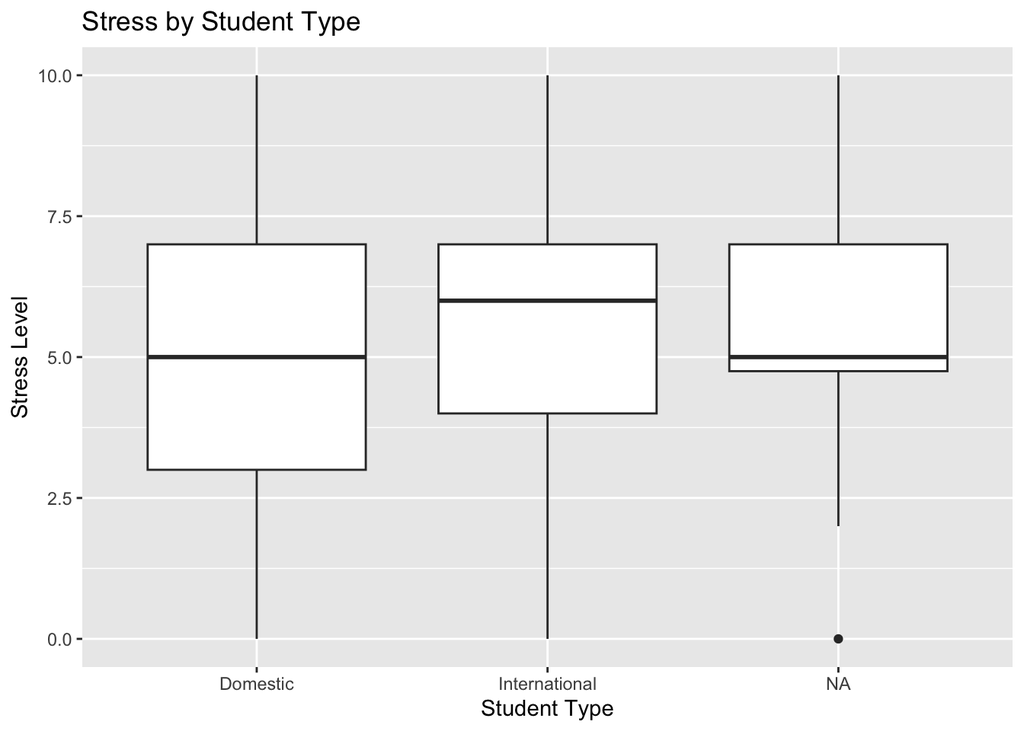

```r
suppressPackageStartupMessages(library(ggplot2))
library(ggplot2)

ggplot(df, aes(x = student_type, y = stress)) +
  geom_boxplot() +
  labs(
    x = "Student Type",
    y = "Stress Level",
    title = "Stress by Student Type"
  )
```

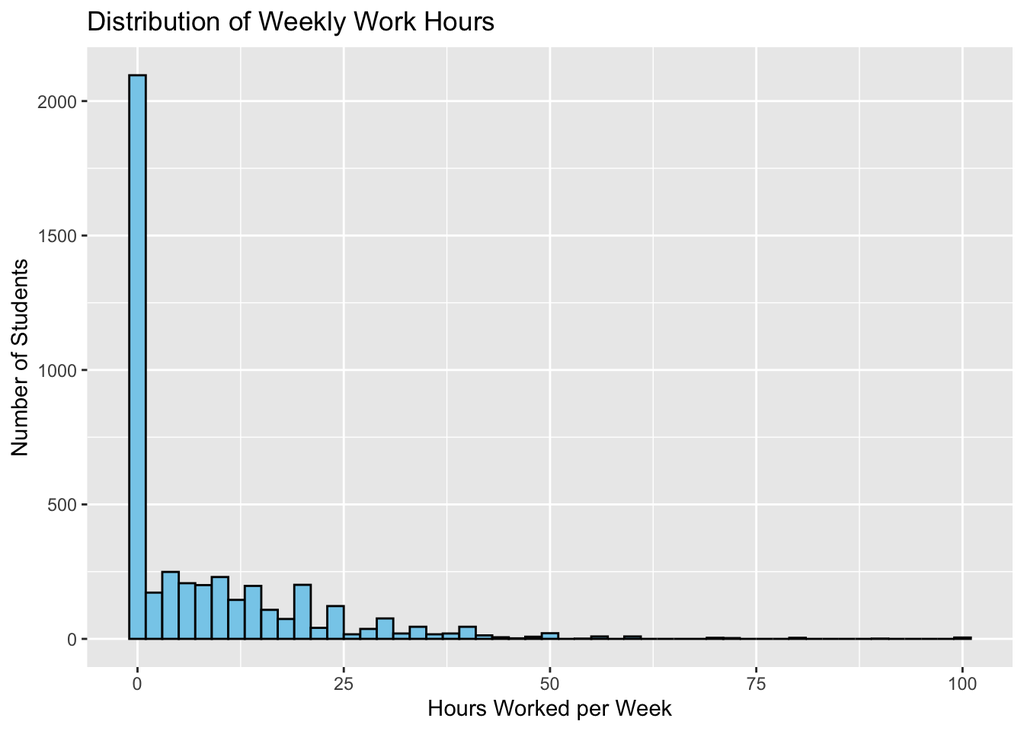

```r
ggplot(df2, aes(hours_work)) +
  geom_histogram(binwidth = 2, fill = "skyblue", color = "black") +
  labs (
    x = "Hours Worked per Week",
    y = "Number of Students",
    title = "Distribution of Weekly Work Hours"
  )
```

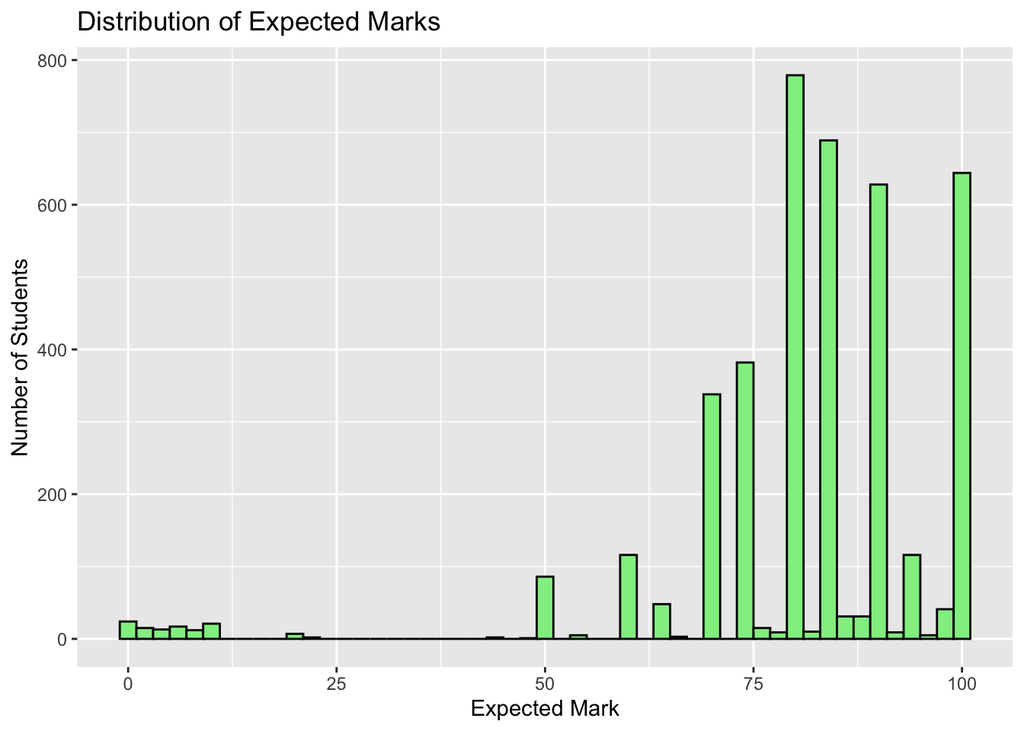

```r
ggplot(df, aes(mark_goal)) +
  geom_histogram(binwidth = 2, fill = "lightgreen", color = "black") +
  labs (
    x = "Expected Mark",
    y = "Number of Students",
    title = "Distribution of Expected Marks"
  )
```

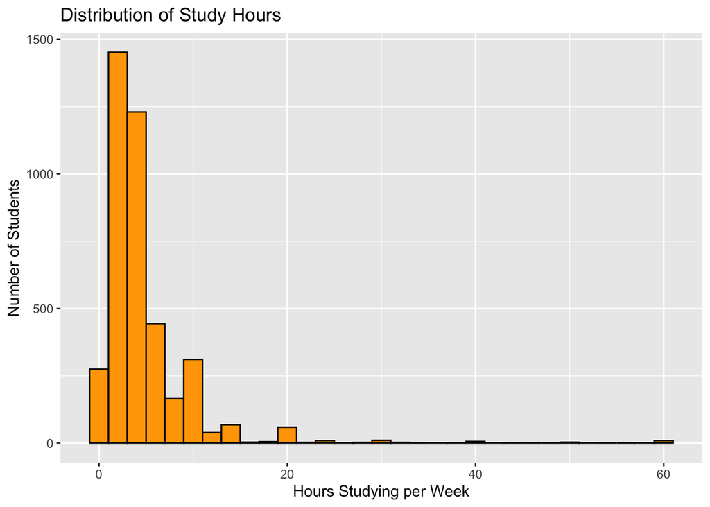

```r
ggplot(df, aes(hours_studying)) +
  geom_histogram(binwidth = 2, fill = "orange", color = "black") +
  labs (
    x = "Hours Studying per Week",
    y = "Number of Students",
    title = "Distribution of Study Hours"
  )
```

## Research Question 2 (Linear Model): Do work hours, study hours, and student type predict stress levels?

A linear model was fitted with stress as the response variable and hours worked, hours studying, and student type as predictors. Hours worked and hours studying both have slopes close to zero, indicating that increases in workload or study time do not systematically raise or lower stress. Student type shows minor differences, consistent with the descriptive summaries showing similar stress distributions for domestic and international students.

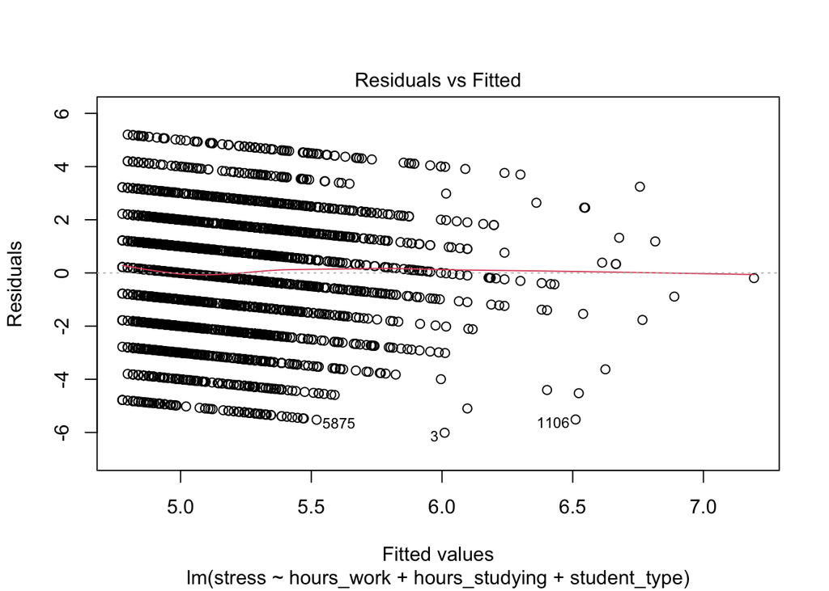

```r
df <- readr::read_csv("~/Documents/DATA1001/Project1/data1001_survey_data_2026S1-1.csv", show_col_types = FALSE)

df2 <- df[df$hours_work <= 100, ]

lm_fit <- lm(stress ~ hours_work + hours_studying + student_type, data = df2)

plot(lm_fit, which = 1)
```

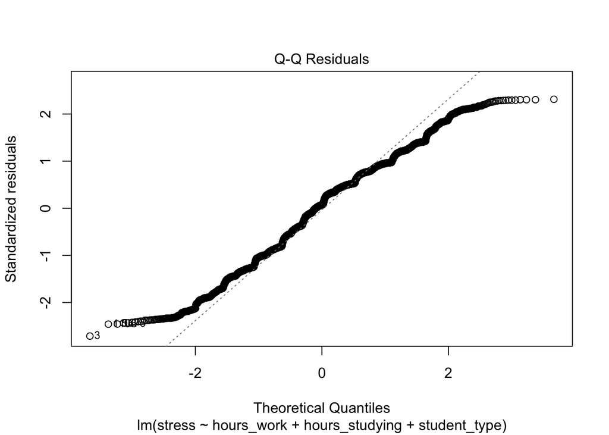

```r
plot(lm_fit, which = 2)
```

## Articles

Nidogon Višnjić, Sonja, Katarina Pažur Aničić, and Blaženka Divjak. 2024. “A Systematic Review of the Literature on Student Work and Academic Performance.” *Industry & Higher Education* 38 (5). https://doi.org/10.1177/09504222241241974.

Thies, Theresa. 2022. “International Students in Higher Education: The Effect of Student Employment on Academic Performance and Study Progress.” *Higher Education* 86: 933–51. https://doi.org/10.1007/s10734-022-00950-5.

Kember, D., NG, S., TSE, H., Wong, E. T. T., & Pomfret, M. (1996). An examination of the interrelationships between workload, study time, learning approaches and academic outcomes. Studies in Higher Education, 21(3), 347–358. https://doi.org/10.1080/03075079612331381261.

Ahmady S, Khajeali N, Kalantarion M, Sharifi F, Yaseri M. Relation between stress, time management, and academic achievement in preclinical medical education: A systematic review and meta-analysis. J Educ Health Promot. 2021 Jan 28;10:32. doi: 10.4103/jehp.jehp_600_20. PMID: 33688541; PMCID: PMC7933620.

## Resources Used

- https://edstem.org/au/courses/30417/discussion/3227691
- https://edstem.org/au/courses/30417/discussion/3225153

# Acknowledgements

**Member Contributions:**

Nick - Writing the code and finalising research questions

Tommy - Creating the Slides and summarising the graphs.

Mitch - Numeric summaries, contribution to limitations, acknowledgements

Raf - Limitations, assumptions and researching for articles

Daniel - Formatting information into the .qmd file, revising the code, and submission.

Harrison - Summarising statistical analysis

Killian - Contributions to research question analysis and references.

| Meeting Dates | Members: |
| --- | --- |
| 2026-02-24 09:00 - 10:00 | All group members (excluding Tommy) |
| 2026-03-03 09:00 - 10:00 | All group members |
| 2026-03-10 09:00 - 10:00 | All group members |
| 2026-03-17 09:00 - 10:00 | All group members (excluding Mitch) |
| 2026-03-24 09:00 - 10:00 | All group members |
| 2026-03-31 09:00 - 10:00 | All group members |
| 2026-04-07 12:00 - 14:00 | All group members (excluding Killian) |

Shared values of truthfulness and integrity were upheld by consistently referring to the verified data rather than assumptions and unverified data. Ethical principles of maintaining confidence in statistics were upheld by only referring to the given dataset and not forging any data.

**AI Usage Statement**

There was no AI used to produce the final version of this project. No content of the final submission of this project contains assistance from AI, including research, analysis and coding.